# BIOL_3100 Final Project

Education & Career Success; Data Analysis and Prediction Model

Myles Ashbaker

# Introduction

This analysis examines which academic and experiential factors predict early career success using the **Education & Career Success** dataset (*n = 5,000*) sourced from Kaggle: [Education and Career Success – by Adil Shamim](https://www.kaggle.com/datasets/adilshamim8/education-and-career-success)

Specifically:

1. **Starting Salary Prediction** – applying multiple linear regression to identify the key drivers of initial compensation (e.g., GPA, internships, soft skills).
2. **Entrepreneurial Propensity** – using logistic regression and threshold tuning to understand which attributes influence the likelihood of pursuing entrepreneurship after graduation.

The goal of this study is to provide actionable insights that can help students, educators, and academic advisors better understand which factors most strongly influence early-career salary and the likelihood of pursuing entrepreneurship. By identifying these key drivers, the findings aim to support more informed decision-making around course selection, skill development, and career planning.

# Data Loading & Cleaning

### Thought Process

- Standardize column names for tidy handling
- Remove the identifier column
- Convert categorical variables to factors for proper modeling

```r
df <- read_csv("../../Data/MRA_education_career_success.csv", show_col_types = FALSE)

df <- janitor::clean_names(df)

df$student_id <- NULL

df <- df %>%
  mutate(
    entrepreneurship   = factor(entrepreneurship, levels = c("No","Yes")),
    gender             = factor(gender),
    field_of_study     = factor(field_of_study),
    current_job_level  = factor(current_job_level)
  )

glimpse(df)
```

```
## Rows: 5,000
## Columns: 19
## $ age                   <dbl> 24, 21, 28, 25, 22, 24, 27, 20, 24, 28, 28, 25, …
## $ gender                <fct> Male, Other, Female, Male, Male, Male, Male, Mal…
## $ high_school_gpa       <dbl> 3.58, 2.52, 3.42, 2.43, 2.08, 2.40, 2.36, 2.68, …
## $ sat_score             <dbl> 1052, 1211, 1193, 1497, 1012, 1600, 1011, 1074, …
## $ university_ranking    <dbl> 291, 112, 715, 170, 599, 631, 610, 240, 337, 138…
## $ university_gpa        <dbl> 3.96, 3.63, 2.63, 2.81, 2.48, 3.78, 3.83, 2.84, …
## $ field_of_study        <fct> Arts, Law, Medicine, Computer Science, Engineeri…
## $ internships_completed <dbl> 3, 4, 4, 3, 4, 2, 0, 1, 2, 1, 2, 2, 2, 0, 1, 3, …
## $ projects_completed    <dbl> 7, 7, 8, 9, 6, 3, 1, 5, 3, 5, 7, 2, 0, 4, 2, 5, …
## $ certifications        <dbl> 2, 3, 1, 1, 4, 2, 3, 5, 0, 3, 5, 3, 5, 3, 3, 2, …
## $ soft_skills_score     <dbl> 9, 8, 1, 10, 10, 2, 3, 5, 5, 10, 8, 2, 2, 8, 1, …
## $ networking_score      <dbl> 8, 1, 9, 6, 9, 2, 3, 1, 5, 2, 1, 9, 9, 6, 8, 9, …
## $ job_offers            <dbl> 5, 4, 0, 1, 4, 1, 2, 2, 2, 0, 5, 5, 2, 2, 1, 3, …
## $ starting_salary       <dbl> 27200, 25000, 42400, 57400, 47600, 68400, 55500,…
## $ career_satisfaction   <dbl> 4, 1, 9, 7, 9, 9, 7, 2, 2, 4, 9, 7, 9, 4, 9, 7, …
## $ years_to_promotion    <dbl> 5, 1, 3, 5, 5, 2, 4, 3, 2, 2, 1, 4, 4, 3, 3, 4, …
## $ current_job_level     <fct> Entry, Mid, Entry, Mid, Entry, Entry, Mid, Entry…
## $ work_life_balance     <dbl> 7, 7, 7, 5, 2, 8, 3, 3, 2, 2, 2, 6, 8, 3, 6, 3, …
## $ entrepreneurship      <fct> No, No, No, No, No, Yes, No, No, No, No, No, Yes…
```

# Exploratory Data Analysis

### Pairwise Numeric Scatterplots

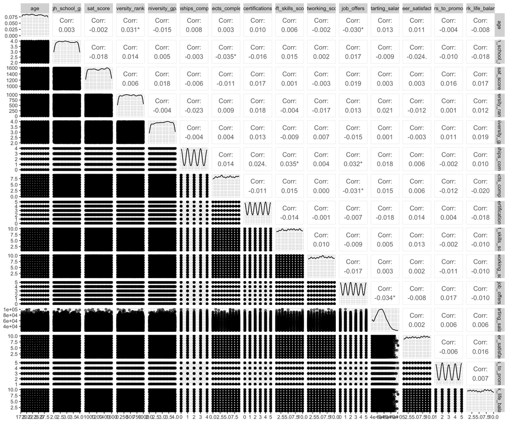

```r
num_cols <- names(df)[vapply(df, is.numeric, logical(1))]
GGally::ggpairs(df, columns = num_cols, aes(alpha = 0.4))
```